# 家庭外籍看護工——假別制度深度分析

勞動部移工管理及運用調查｜113年6月

分析報告

2026-05-03

# 前言

> 家庭看護工不適用《勞基法》，沒有法定的例假日與休息日。 他們能否放假、放多久、有沒有加班費，完全取決於雇主。 本報告拆解放假制度的**每一個環節**—— 從「有沒有假」到「每次放多久」，從「加班費能補償嗎」到 「性別平等假為何幾乎沒人敢申請」。

> 資料來源：勞動部「移工管理及運用調查」113 年家庭面問卷（N = 4,016）

```r
library(tidyverse)
library(scales)
library(patchwork)
library(broom)
library(knitr)
library(ggplot2)

theme_set(
  theme_minimal(base_family = "Microsoft JhengHei", base_size = 13) +
    theme(
      plot.title    = element_text(face = "bold", size = 16),
      plot.subtitle = element_text(color = "grey40", size = 12),
      plot.caption  = element_text(color = "grey60", size = 9),
      legend.position = "bottom",
      panel.grid.minor = element_blank()
    )
)

pal2   <- c("#3498DB", "#E74C3C")
pal3   <- c("#27AE60", "#F39C12", "#E74C3C")
pal4   <- c("#27AE60", "#3498DB", "#F39C12", "#E74C3C")
```

```r
raw <- read_csv("data113.csv", locale = locale(encoding = "UTF-8"),
                show_col_types = FALSE)

city_map <- c(
  "1"="新北市","2"="臺北市","3"="桃園市","4"="臺中市","5"="臺南市","6"="高雄市",
  "7"="宜蘭縣","8"="新竹縣","9"="苗栗縣","10"="彰化縣","11"="南投縣","12"="雲林縣",
  "13"="嘉義縣","14"="屏東縣","15"="臺東縣","16"="花蓮縣","17"="澎湖縣",
  "18"="基隆市","19"="新竹市","20"="嘉義市","21"="金門連江"
)
six_cities <- c("新北市","臺北市","桃園市","臺中市","臺南市","高雄市")

df <- raw %>%
  mutate(
    縣市 = recode(as.character(j1), !!!city_map),
    都會類型 = factor(ifelse(縣市 %in% six_cities, "六都", "非六都"),
                    levels = c("六都", "非六都")),

    # 移工背景
    性別     = factor(q8a, levels = 1:2, labels = c("男", "女")),
    年齡組   = factor(q8b, levels = 1:4,
                    labels = c("<25歲", "25-34歲", "35-44歲", "45歲以上")),
    教育程度 = factor(q8c, levels = 1:3,
                    labels = c("國中及以下", "高中(職)", "專科及以上")),
    國籍     = factor(q8d, levels = 1:4,
                    labels = c("印尼", "菲律賓", "泰國", "越南")),
    護理訓練 = factor(q8e, levels = 1:2, labels = c("有訓練", "無訓練")),

    # 雇主背景
    曾僱本國 = factor(q4, levels = 1:2, labels = c("未曾", "曾僱用")),

    # === 放假核心變項 ===
    放假頻率 = factor(q13a, levels = c(1, 2, 3, 5),
                    labels = c("都有放假\n(4-5次/月)", "每月1次",
                               "每月2-3次", "完全不放假")),
    放假三分 = case_when(
      q13a == 1 ~ "充分放假 (4-5次)",
      q13a %in% c(2, 3) ~ "部分放假 (1-3次)",
      q13a == 5 ~ "完全不放假",
      TRUE ~ NA_character_
    ),
    放假三分 = factor(放假三分, levels = c("充分放假 (4-5次)",
                                          "部分放假 (1-3次)",
                                          "完全不放假")),

    每次放假時數 = as.numeric(nq13b),
    放假時數分組 = case_when(
      is.na(每次放假時數) | q13a == 5 ~ NA_character_,
      每次放假時數 <= 8  ~ "≤ 8 小時",
      每次放假時數 <= 12 ~ "9-12 小時",
      TRUE ~ "> 12 小時"
    ),
    放假時數分組 = factor(放假時數分組,
                        levels = c("≤ 8 小時", "9-12 小時", "> 12 小時")),

    # === 薪資 ===
    月薪     = as.numeric(nq10a),
    加班費   = as.numeric(nq10ab),
    總薪資   = 月薪 + 加班費,
    權重     = as.numeric(w),

    # 薪資支付
    薪資支付 = case_when(
      q11 == 1 ~ "現金",
      q11 == 2 ~ "匯入銀行",
      q11 %in% c(3,4) ~ "其他",
      TRUE ~ NA_character_
    ),

    # === 替代方案 ===
    有替代方案 = factor(q16, levels = 1:2, labels = c("有", "沒有")),
    替代方案類型 = case_when(
      q16a == 1 ~ "家人照顧",
      q16a == 2 ~ "政府喘息服務",
      q16a %in% 3:6 ~ "其他",
      TRUE ~ NA_character_
    ),

    # === 政策與假別 ===
    願意休假 = factor(q17, levels = 1:3,
                    labels = c("願意", "不願意", "不確定")),
    有輪替   = factor(q15, levels = 1:2, labels = c("有", "無")),

    曾申請性平假 = factor(q18, levels = 1:2, labels = c("未提出", "有提出")),

    # === 結果 ===
    有困擾   = factor(q6, levels = 1:2, labels = c("無", "有")),
    困擾_01  = ifelse(q6 == 2, 1, 0),
    整體滿意 = as.numeric(q20_7),
    曾逃跑   = factor(q5, levels = 1:2, labels = c("否", "是")),
    逃跑_01  = ifelse(q5 == 2, 1, 0)
  )
```

# 1. 放假頻率：四成移工沒有任何假日

## 1.1 放假頻率分布

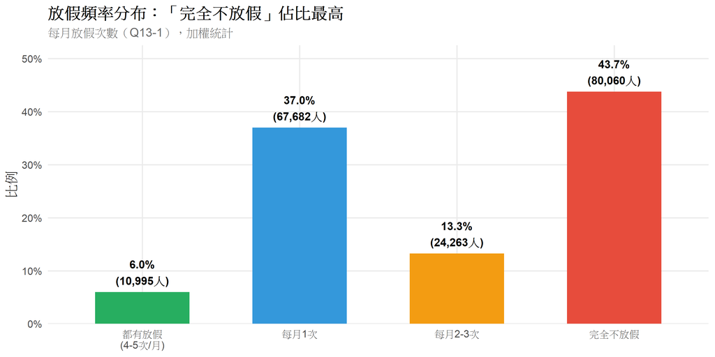

```r
df %>%
  filter(!is.na(放假頻率)) %>%
  count(放假頻率, wt = 權重) %>%
  mutate(pct = n / sum(n),
         人數 = round(n)) %>%
  ggplot(aes(x = 放假頻率, y = pct, fill = 放假頻率)) +
  geom_col(width = 0.6, show.legend = FALSE) +
  geom_text(aes(label = paste0(percent(pct, 0.1), "\n(", comma(人數), "人)")),
            vjust = -0.3, fontface = "bold", size = 4) +
  scale_fill_manual(values = pal4) +
  scale_y_continuous(labels = percent, expand = expansion(mult = c(0, 0.2))) +
  labs(title = "放假頻率分布：「完全不放假」佔比最高",
       subtitle = "每月放假次數（Q13-1），加權統計",
       x = NULL, y = "比例")
```

## 1.2 放假頻率的移工背景差異

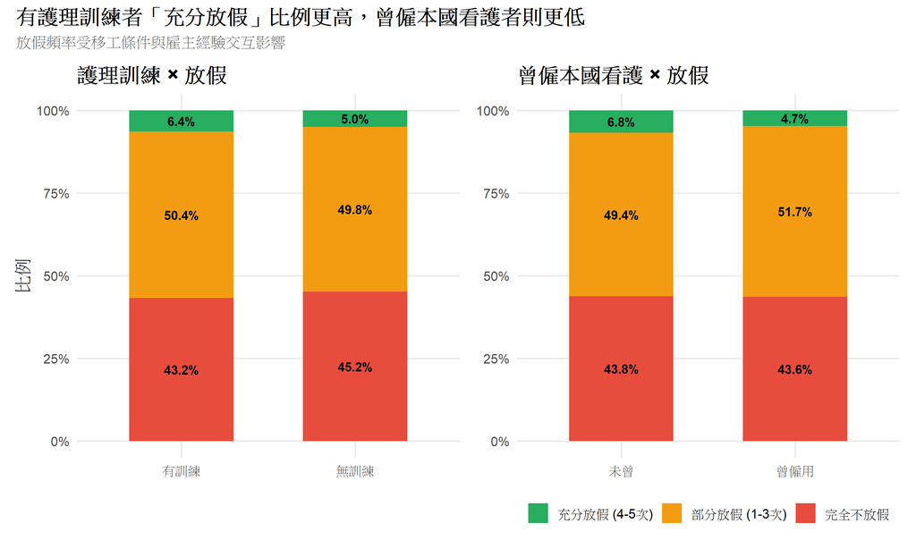

```r
p1 <- df %>%
  filter(!is.na(放假三分), !is.na(護理訓練)) %>%
  count(護理訓練, 放假三分, wt = 權重) %>%
  group_by(護理訓練) %>%
  mutate(pct = n / sum(n)) %>%
  ggplot(aes(x = 護理訓練, y = pct, fill = 放假三分)) +
  geom_col(width = 0.6) +
  geom_text(aes(label = percent(pct, 0.1)),
            position = position_stack(vjust = 0.5), size = 3.5, fontface = "bold") +
  scale_fill_manual(values = pal3) +
  scale_y_continuous(labels = percent) +
  labs(title = "護理訓練 × 放假", x = NULL, y = "比例") +
  theme(legend.position = "none")

p2 <- df %>%
  filter(!is.na(放假三分), !is.na(曾僱本國)) %>%
  count(曾僱本國, 放假三分, wt = 權重) %>%
  group_by(曾僱本國) %>%
  mutate(pct = n / sum(n)) %>%
  ggplot(aes(x = 曾僱本國, y = pct, fill = 放假三分)) +
  geom_col(width = 0.6) +
  geom_text(aes(label = percent(pct, 0.1)),
            position = position_stack(vjust = 0.5), size = 3.5, fontface = "bold") +
  scale_fill_manual(values = pal3) +
  scale_y_continuous(labels = percent) +
  labs(title = "曾僱本國看護 × 放假", x = NULL, y = NULL) +
  theme(legend.title = element_blank())

p1 + p2 +
  plot_annotation(
    title = "有護理訓練者「充分放假」比例更高，曾僱本國看護者則更低",
    subtitle = "放假頻率受移工條件與雇主經驗交互影響"
  )
```

# 2. 每次放假多久？「半天假」的真相

> 即使有放假，每次放多久也至關重要。以下僅分析「有放假」的移工。

## 2.1 放假時數分布

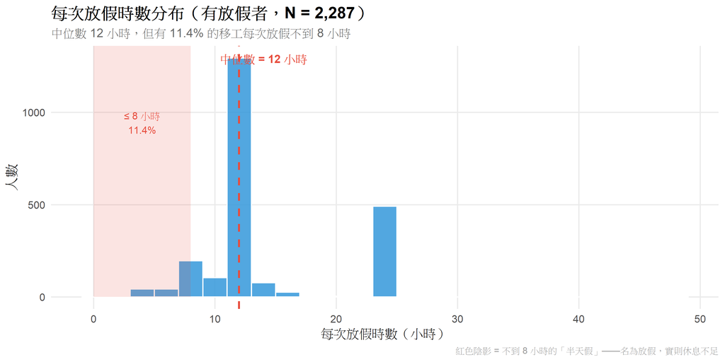

```r
df %>%
  filter(!is.na(每次放假時數), 每次放假時數 > 0, 放假三分 != "完全不放假") %>%
  ggplot(aes(x = 每次放假時數)) +
  geom_histogram(binwidth = 2, fill = "#3498DB", color = "white", alpha = 0.85) +
  geom_vline(xintercept = 12, color = "#E74C3C", linewidth = 1, linetype = "dashed") +
  annotate("text", x = 14, y = Inf, vjust = 2,
           label = "中位數 = 12 小時", color = "#E74C3C", fontface = "bold", size = 4) +
  annotate("rect", xmin = 0, xmax = 8, ymin = 0, ymax = Inf,
           alpha = 0.15, fill = "#E74C3C") +
  annotate("text", x = 4, y = Inf, vjust = 4,
           label = "≤ 8 小時\n11.4%", color = "#E74C3C", size = 3.5) +
  labs(title = "每次放假時數分布（有放假者，N = 2,287）",
       subtitle = "中位數 12 小時，但有 11.4% 的移工每次放假不到 8 小時",
       caption = "紅色陰影 = 不到 8 小時的「半天假」——名為放假，實則休息不足",
       x = "每次放假時數（小時）", y = "人數")
```

## 2.2 放假時數三分組

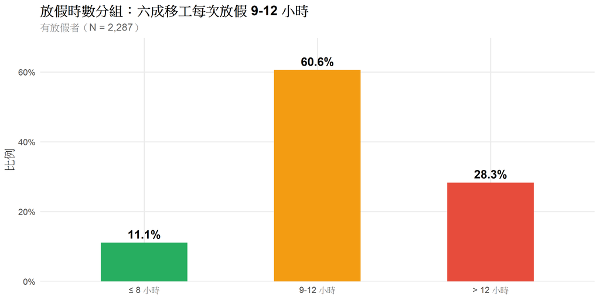

```r
df %>%
  filter(!is.na(放假時數分組)) %>%
  count(放假時數分組, wt = 權重) %>%
  mutate(pct = n / sum(n)) %>%
  ggplot(aes(x = 放假時數分組, y = pct, fill = 放假時數分組)) +
  geom_col(width = 0.5, show.legend = FALSE) +
  geom_text(aes(label = percent(pct, 0.1)),
            vjust = -0.5, fontface = "bold", size = 5) +
  scale_fill_manual(values = pal3) +
  scale_y_continuous(labels = percent, expand = expansion(mult = c(0, 0.15))) +
  labs(title = "放假時數分組：六成移工每次放假 9-12 小時",
       subtitle = "有放假者（N = 2,287）",
       x = NULL, y = "比例")
```